# HW_5_Popova

Popova Svetlana

2024-04-07

**Постройте графики, на которых отразите регрессионную прямую, и прокомментируйте свои находки.**

### (а) Связь среднего радиуса и средней площади опухоли

```r
# Загружаем датасет
data <- read.csv("wisconsin_breast_cancer.csv")

# Создаем регрессионную модель
model_a <- lm(area_mean ~ radius_mean, data = data)

# Выводим результаты модели
summary(model_a)
```

```
##
## Call:
## lm(formula = area_mean ~ radius_mean, data = data)
##
## Residuals:
##    Min     1Q Median     3Q    Max
## -76.30 -34.87 -13.66  16.99 535.47
##
## Coefficients:
##              Estimate Std. Error t value Pr(>|t|)
## (Intercept) -738.0367     9.6785  -76.25   <2e-16 ***
## radius_mean   98.5982     0.6648  148.32   <2e-16 ***
## ---
## Signif. codes:  0 '***' 0.001 '**' 0.01 '*' 0.05 '.' 0.1 ' ' 1
##
## Residual standard error: 55.83 on 567 degrees of freedom
## Multiple R-squared:  0.9749, Adjusted R-squared:  0.9748
## F-statistic: 2.2e+04 on 1 and 567 DF,  p-value: < 2.2e-16
```

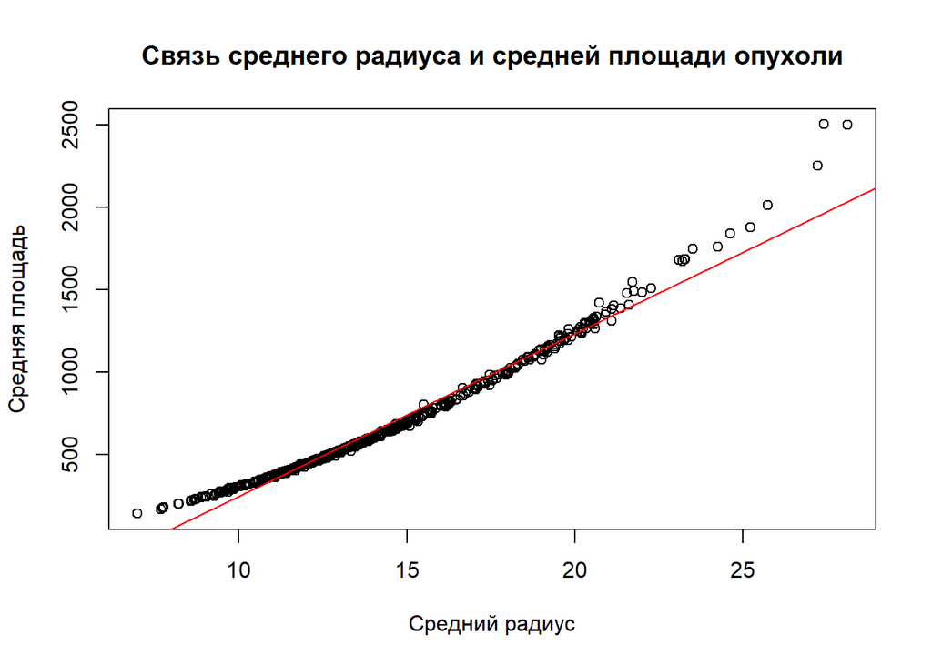

```r
# Строим график
plot(data$radius_mean, data$area_mean, main = "Связь среднего радиуса и средней площади опухоли", xlab = "Средний радиус", ylab = "Средняя площадь")
abline(model_a, col = "red")
```

**Вывод:** Модель показывает сильную положительную корреляцию между средним радиусом и средней площадью опухоли. Это ожидаемо, так как площадь круга (а опухоль часто аппроксимируется кругом) пропорциональна квадрату радиуса.

### (б) Связь среднего радиуса и среднего периметра опухоли

```r
# Создаем регрессионную модель
model_b <- lm(perimeter_mean ~ radius_mean, data = data)

# Выводим результаты модели
summary(model_b)
```

```
##
## Call:
## lm(formula = perimeter_mean ~ radius_mean, data = data)
##
## Residuals:
##     Min      1Q  Median      3Q     Max
## -4.0708 -0.9788 -0.2306  0.7129 10.0859
##
## Coefficients:
##             Estimate Std. Error t value Pr(>|t|)
## (Intercept) -5.23239    0.27597  -18.96   <2e-16 ***
## radius_mean  6.88040    0.01895  362.99   <2e-16 ***
## ---
## Signif. codes:  0 '***' 0.001 '**' 0.01 '*' 0.05 '.' 0.1 ' ' 1
##
## Residual standard error: 1.592 on 567 degrees of freedom
## Multiple R-squared:  0.9957, Adjusted R-squared:  0.9957
## F-statistic: 1.318e+05 on 1 and 567 DF,  p-value: < 2.2e-16
```

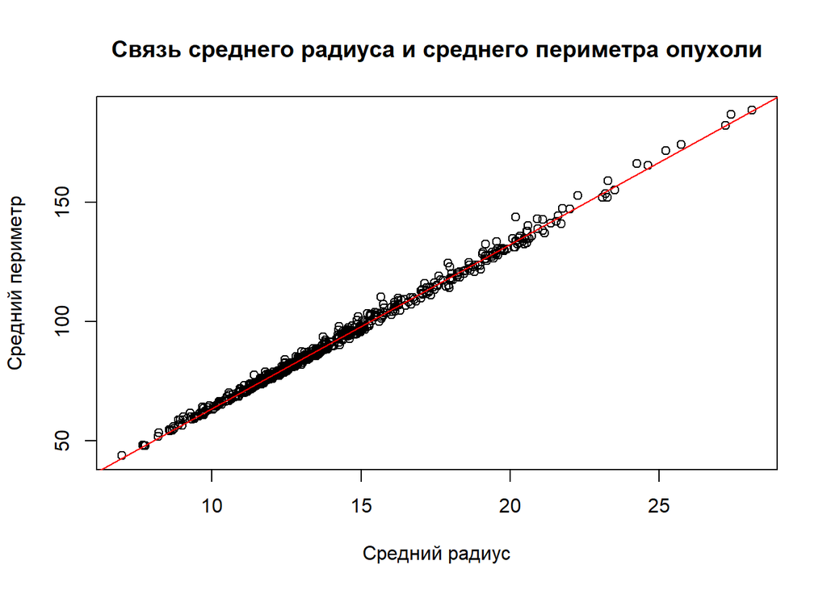

```r
# Строим график
plot(data$radius_mean, data$perimeter_mean, main = "Связь среднего радиуса и среднего периметра опухоли", xlab = "Средний радиус", ylab = "Средний периметр")
abline(model_b, col = "red")
```

Вывод: модель показывает сильную положительную корреляцию между средним радиусом и средним периметром опухоли. Это также ожидаемо, так как периметр круга пропорционален радиусу.

### (в) Связь среднего радиуса и средней симметричности опухоли

```r
# Создаем регрессионную модель
model_c <- lm(symmetry_mean ~ radius_mean, data = data)

# Выводим результаты модели
summary(model_c)
```

```
##
## Call:
## lm(formula = symmetry_mean ~ radius_mean, data = data)
##
## Residuals:
##      Min       1Q   Median       3Q      Max
## -0.07180 -0.01795 -0.00327  0.01524  0.11938
##
## Coefficients:
##              Estimate Std. Error t value Pr(>|t|)
## (Intercept) 0.1649252  0.0047043  35.058  < 2e-16 ***
## radius_mean 0.0011493  0.0003231   3.557 0.000406 ***
## ---
## Signif. codes:  0 '***' 0.001 '**' 0.01 '*' 0.05 '.' 0.1 ' ' 1
##
## Residual standard error: 0.02714 on 567 degrees of freedom
## Multiple R-squared:  0.02183,    Adjusted R-squared:  0.0201
## F-statistic: 12.65 on 1 and 567 DF,  p-value: 0.0004065
```

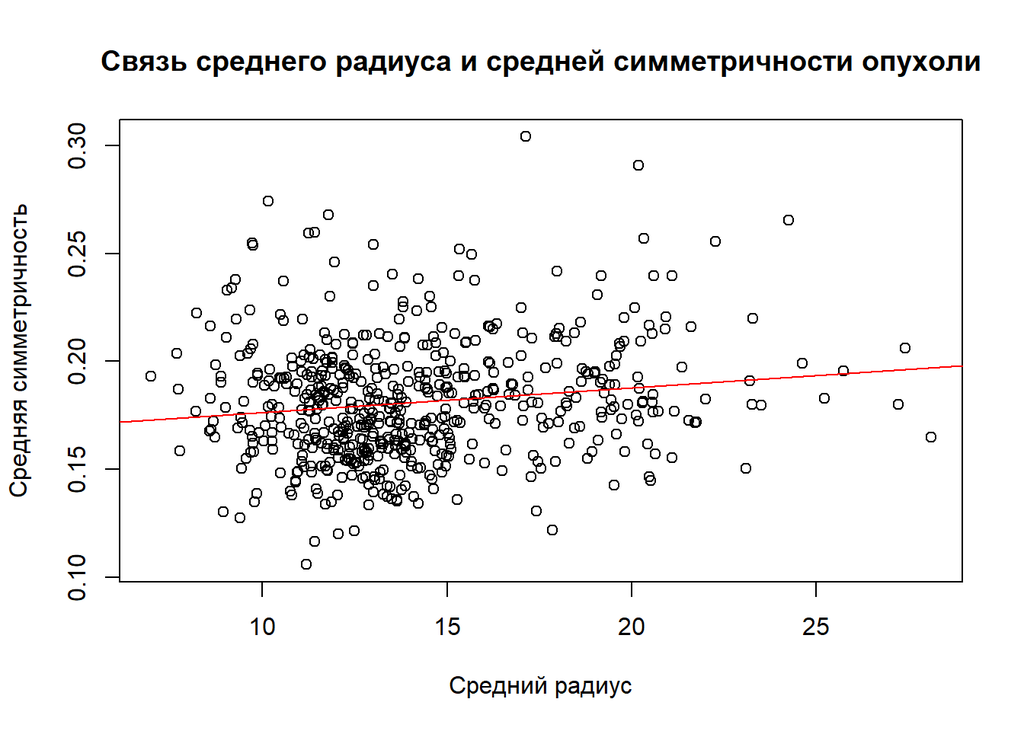

```r
# Строим график
plot(data$radius_mean, data$symmetry_mean, main = "Связь среднего радиуса и средней симметричности опухоли", xlab = "Средний радиус", ylab = "Средняя симметричность")
abline(model_c, col = "red")
```

**Вывод:** модель показывает слабую положительную корреляцию между средним радиусом и средней симметричностью опухоли. Это говорит о том, что с увеличением радиуса опухоли, симметричность может незначительно увеличиваться, но эта связь не столь сильна, как в предыдущих случаях.

## Задание 2

### (а) Вероятность злокачественной опухоли от среднего радиуса

```r
# Преобразуем диагноз в числовые значения
data$diagnosis <- ifelse(data$diagnosis == "M", 1, 0)

# Создаем логистическую регрессионную модель
model_a <- glm(diagnosis ~ radius_mean, data = data, family = binomial)

# Выводим результаты модели
summary(model_a)
```

```
##
## Call:
## glm(formula = diagnosis ~ radius_mean, family = binomial, data = data)
##
## Coefficients:
##              Estimate Std. Error z value Pr(>|z|)
## (Intercept) -15.24587    1.32463  -11.51   <2e-16 ***
## radius_mean   1.03359    0.09311   11.10   <2e-16 ***
## ---
## Signif. codes:  0 '***' 0.001 '**' 0.01 '*' 0.05 '.' 0.1 ' ' 1
##
## (Dispersion parameter for binomial family taken to be 1)
##
##     Null deviance: 751.44  on 568  degrees of freedom
## Residual deviance: 330.01  on 567  degrees of freedom
## AIC: 334.01
##
## Number of Fisher Scoring iterations: 6
```

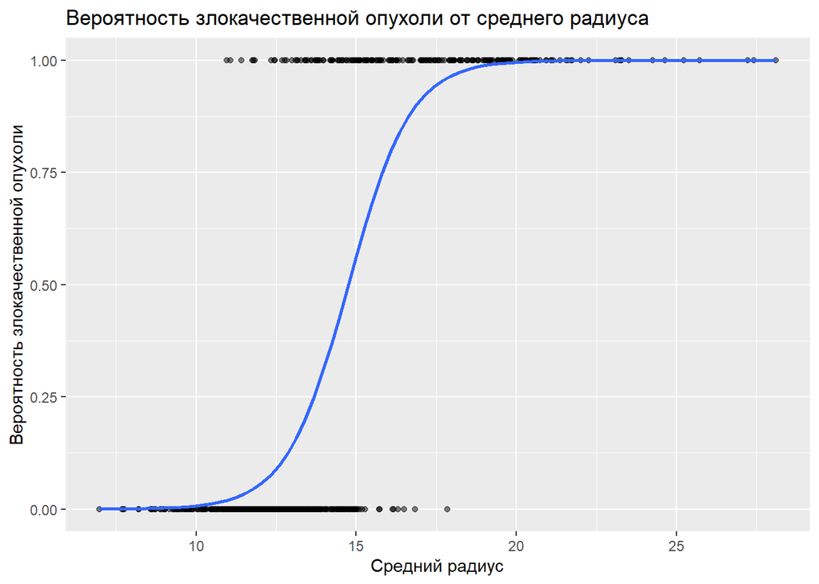

```r
# Строим график
library(ggplot2)
ggplot(data, aes(x = radius_mean, y = diagnosis)) +
  geom_point(alpha = 0.5) +
  stat_smooth(method = "glm", method.args = list(family = "binomial"), se = FALSE) +
  labs(title = "Вероятность злокачественной опухоли от среднего радиуса", x = "Средний радиус", y = "Вероятность злокачественной опухоли")
```

- Существует статистически значимая связь между средним радиусом опухоли и вероятностью ее злокачественности. Это подтверждается очень низкими p-значениями (<< 2e-16) как для константы, так и для коэффициента при переменной radius_mean.
- С увеличением среднего радиуса опухоли вероятность ее злокачественности также увеличивается. Это следует из положительного значения коэффициента при radius_mean (1.03359). Другими словами, чем больше размер опухоли, тем выше шансы, что она является злокачественной.
- Модель достаточно хорошо объясняет вариацию данных. Остаточный девианс (330.01) значительно меньше нулевого девианса (751.44), что указывает на то, что включение переменной radius_mean в модель улучшает ее способность описывать данные.

### (б) Вероятность злокачественной опухоли от средней площади

```r
# Создаем логистическую регрессионную модель
model_b <- glm(diagnosis ~ area_mean, data = data, family = binomial)

# Выводим результаты модели
summary(model_b)
```

```
##
## Call:
## glm(formula = diagnosis ~ area_mean, family = binomial, data = data)
##
## Coefficients:
##             Estimate Std. Error z value Pr(>|z|)
## (Intercept) -7.97409    0.68286  -11.68   <2e-16 ***
## area_mean    0.01177    0.00109   10.80   <2e-16 ***
## ---
## Signif. codes:  0 '***' 0.001 '**' 0.01 '*' 0.05 '.' 0.1 ' ' 1
##
## (Dispersion parameter for binomial family taken to be 1)
##
##     Null deviance: 751.44  on 568  degrees of freedom
## Residual deviance: 325.66  on 567  degrees of freedom
## AIC: 329.66
##
## Number of Fisher Scoring iterations: 7
```

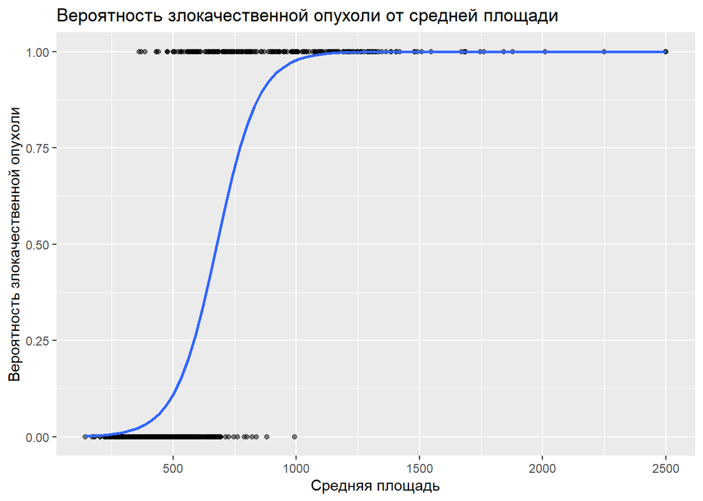

```r
# Строим график
ggplot(data, aes(x = area_mean, y = diagnosis)) +
  geom_point(alpha = 0.5) +
  stat_smooth(method = "glm", method.args = list(family = "binomial"), se = FALSE) +
  labs(title = "Вероятность злокачественной опухоли от средней площади", x = "Средняя площадь", y = "Вероятность злокачественной опухоли")
```

- Существует статистически значимая связь между средней площадью опухоли и вероятностью ее злокачественности. Это подтверждается очень низкими p-значениями (<< 2e-16) как для константы, так и для коэффициента при переменной area_mean.
- С увеличением средней площади опухоли вероятность ее злокачественности также увеличивается. Это следует из положительного значения коэффициента при area_mean (0.01177). Другими словами, чем больше площадь опухоли, тем выше шансы, что она является злокачественной.
- Модель достаточно хорошо объясняет вариацию данных**.** Остаточный девианс (325.66) заметно меньше нулевого девианса (751.44), что указывает на то, что включение переменной area_mean в модель улучшает ее способность описывать данные.

### (в) Вероятность злокачественной опухоли от средней текстуры

```r
# Создаем логистическую регрессионную модель
model_c <- glm(diagnosis ~ texture_mean, data = data, family = binomial)

# Выводим результаты модели
summary(model_c)
```

```
##
## Call:
## glm(formula = diagnosis ~ texture_mean, family = binomial, data = data)
##
## Coefficients:
##              Estimate Std. Error z value Pr(>|z|)
## (Intercept)  -5.12577    0.52638  -9.738   <2e-16 ***
## texture_mean  0.23464    0.02614   8.975   <2e-16 ***
## ---
## Signif. codes:  0 '***' 0.001 '**' 0.01 '*' 0.05 '.' 0.1 ' ' 1
##
## (Dispersion parameter for binomial family taken to be 1)
##
##     Null deviance: 751.44  on 568  degrees of freedom
## Residual deviance: 646.52  on 567  degrees of freedom
## AIC: 650.52
##
## Number of Fisher Scoring iterations: 4
```

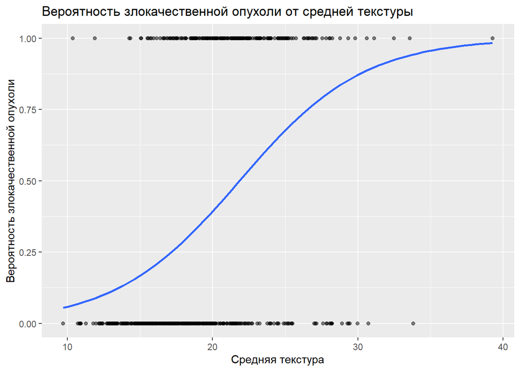

```r
# Строим график
ggplot(data, aes(x = texture_mean, y = diagnosis)) +
  geom_point(alpha = 0.5) +
  stat_smooth(method = "glm", method.args = list(family = "binomial"), se = FALSE) +
  labs(title = "Вероятность злокачественной опухоли от средней текстуры", x = "Средняя текстура", y = "Вероятность злокачественной опухоли")
```

- Существует статистически значимая связь между средней текстурой опухоли и вероятностью ее злокачественности. Это подтверждается очень низкими p-значениями (< 2e-16) как для константы, так и для коэффициента при переменной texture_mean.
- С увеличением средней текстуры опухоли вероятность ее злокачественности также увеличивается. Это следует из положительного значения коэффициента при texture_mean (0.23464). Другими словами, более выраженная текстура опухоли связана с более высоким шансом ее злокачественности.
- Модель объясняет часть вариации данных, но не так хорошо, как модели с радиусом и площадью. Остаточный девианс (646.52) меньше нулевого девианса (751.44), но разница не столь существенна, как в предыдущих моделях. Это говорит о том, что средняя текстура, хотя и связана с вероятностью злокачественности, может быть не таким сильным предиктором, как средний радиус и средняя площадь.

### Модель с тремя факторами

```r
# Создаем логистическую регрессионную модель с тремя факторами
model_all <- glm(diagnosis ~ radius_mean + area_mean + texture_mean, data = data, family = binomial)

# Выводим результаты модели
summary(model_all)
```

```
##
## Call:
## glm(formula = diagnosis ~ radius_mean + area_mean + texture_mean,
##     family = binomial, data = data)
##
## Coefficients:
##              Estimate Std. Error z value Pr(>|z|)
## (Intercept)  -9.48796    6.88503  -1.378    0.168
## radius_mean  -0.38523    0.95524  -0.403    0.687
## area_mean     0.01636    0.01100   1.487    0.137
## texture_mean  0.20917    0.03714   5.632 1.78e-08 ***
## ---
## Signif. codes:  0 '***' 0.001 '**' 0.01 '*' 0.05 '.' 0.1 ' ' 1
##
## (Dispersion parameter for binomial family taken to be 1)
##
##     Null deviance: 751.44  on 568  degrees of freedom
## Residual deviance: 288.81  on 565  degrees of freedom
## AIC: 296.81
##
## Number of Fisher Scoring iterations: 7
```

- Модель статистически значима и объясняет значительную часть вариации данных. Остаточный девианс (288.81) существенно меньше, чем в моделях с одним предиктором и нулевой модели (751.44), что указывает на улучшение качества модели при учете всех трех факторов.
- Средняя текстура остается единственным статистически значимым предиктором в этой модели. Коэффициент при texture_mean имеет очень низкое p-значение (1.78e-08), обозначенное ***, что подтверждает значимость влияния текстуры на вероятность злокачественности.
- Влияние среднего радиуса и средней площади на вероятность злокачественности становится незначимым при учете текстуры. Коэффициенты при radius_mean и area_mean имеют высокие p-значения (0.687 и 0.137 соответственно), что говорит об отсутствии статистически значимого влияния этих факторов на вероятность злокачественности в данной модели.

## Задание 3

```r
# Установка пакета survival
#install.packages("survival")

# Загрузка пакета и датасета
library(survival)
data(lung)

# Создание переменной event
lung$event <- ifelse(lung$status == 2, 1, 0)

# Просмотр структуры датасета
str(lung)
```

```
## 'data.frame':    228 obs. of  11 variables:
##  $ inst     : num  3 3 3 5 1 12 7 11 1 7 ...
##  $ time     : num  306 455 1010 210 883 ...
##  $ status   : num  2 2 1 2 2 1 2 2 2 2 ...
##  $ age      : num  74 68 56 57 60 74 68 71 53 61 ...
##  $ sex      : num  1 1 1 1 1 1 2 2 1 1 ...
##  $ ph.ecog  : num  1 0 0 1 0 1 2 2 1 2 ...
##  $ ph.karno : num  90 90 90 90 100 50 70 60 70 70 ...
##  $ pat.karno: num  100 90 90 60 90 80 60 80 80 70 ...
##  $ meal.cal : num  1175 1225 NA 1150 NA ...
##  $ wt.loss  : num  NA 15 15 11 0 0 10 1 16 34 ...
##  $ event    : num  1 1 0 1 1 0 1 1 1 1 ...
```

1. Построим кривые выживаемости в зависимости от пола:

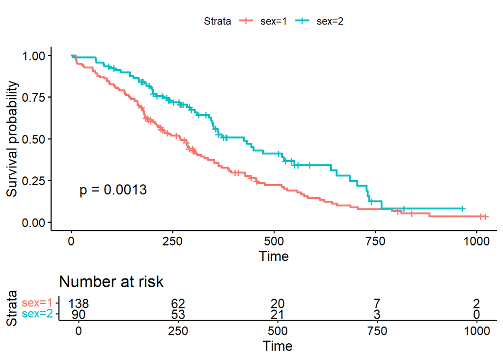

```r
# Создаем выживаемость и цензурирование
lung_surv <- Surv(time = lung$time, event = lung$event)

# Строим кривые выживаемости
fit <- survfit(lung_surv ~ lung$sex)

# Построим график
#install.packages("survminer")
library(survminer)
ggsurvplot(fit, data = lung, risk.table = TRUE, pval = TRUE)
```

2. Построим график кумулятивной функции рисков для пола:

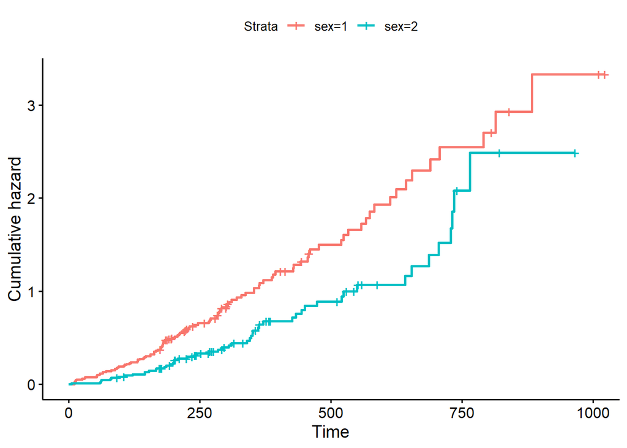

```r
# Построим кумулятивную функцию рисков
fit_cum <- survfit(lung_surv ~ lung$sex)

# Построим график кумулятивной функции рисков
ggsurvplot(fit_cum, data = lung, fun = "cumhaz")
```

3. Построим регрессию Кокса и оценим влияние пола на выживаемость:

   ```r
   # Построим регрессию Кокса
   cox_model <- coxph(Surv(time, event) ~ sex, data = lung)

   # Выведем результаты
   summary(cox_model)
   ```

   ```
   ## Call:
   ## coxph(formula = Surv(time, event) ~ sex, data = lung)
   ##
   ##   n= 228, number of events= 165
   ##
   ##        coef exp(coef) se(coef)      z Pr(>|z|)
   ## sex -0.5310    0.5880   0.1672 -3.176  0.00149 **
   ## ---
   ## Signif. codes:  0 '***' 0.001 '**' 0.01 '*' 0.05 '.' 0.1 ' ' 1
   ##
   ##     exp(coef) exp(-coef) lower .95 upper .95
   ## sex     0.588      1.701    0.4237     0.816
   ##
   ## Concordance= 0.579  (se = 0.021 )
   ## Likelihood ratio test= 10.63  on 1 df,   p=0.001
   ## Wald test            = 10.09  on 1 df,   p=0.001
   ## Score (logrank) test = 10.33  on 1 df,   p=0.001
   ```